# Supply Chain Optimization - Notebook 02: Exploratory Data Analysis

**Project:** Supply Chain Cost & Operational Efficiency Analysis  
**Dataset:** [Supply Chain DataSet](https://www.kaggle.com/datasets/amirmotefaker/supply-chain-dataset) - [Amir Motefaker](https://www.kaggle.com/amirmotefaker) (Kaggle)  
**Analyst:** *Jakub Siuda*  
**Date:** *28/03/2026*

# Exploratory Data Analysis

## Distribution of Key Supply Chain Metrics

Let's take a look at some of the key variables in isolation first, to understand the shape and spread of distributions before combining variables.

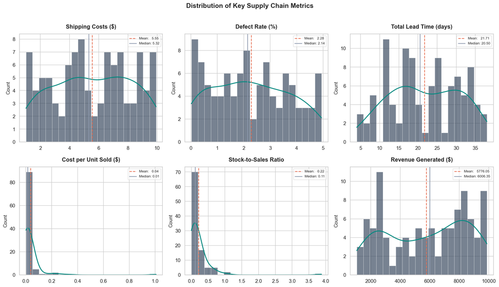

**Cost per unit sold** and **stock-to-sales ratio** are both heavily right-skewed. A small number of SKUs are pulling the mean far above the median. For those two variables, medians will be used for all group comparisons to avoid outlier distortion.

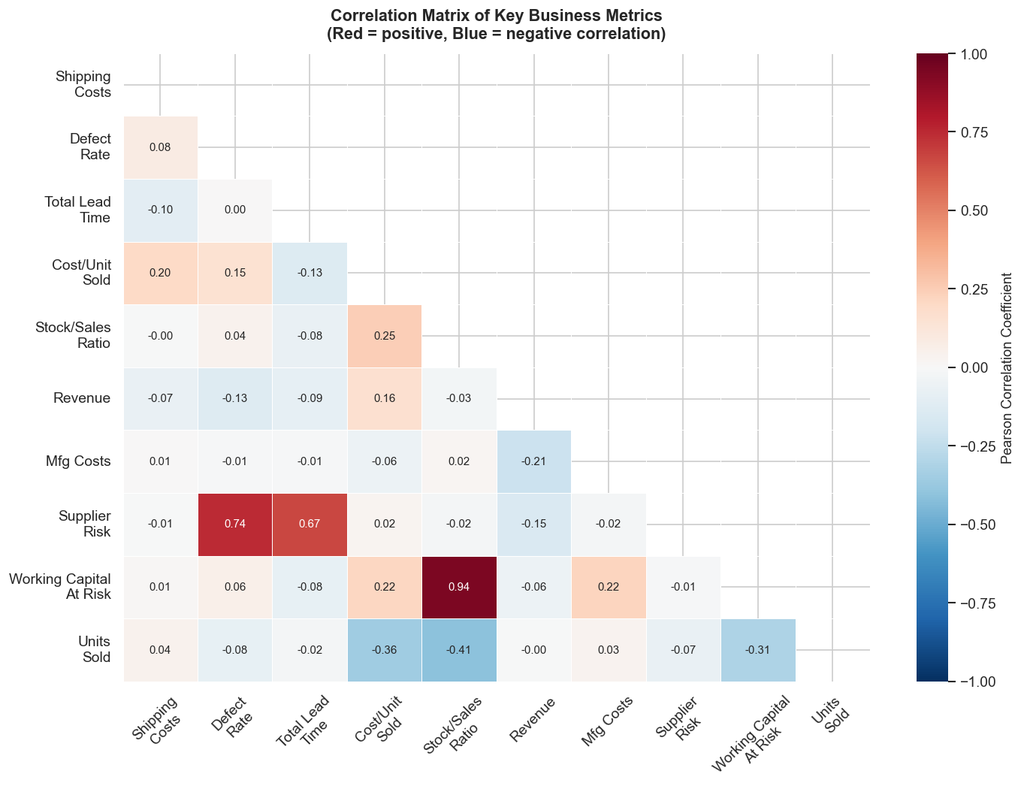

- `Cost/Unit Sold` and `Units Sold` have a negative correlation of ~-0.36: SKUs with higher sales volume naturally have lower per-unit shipping cost, confirming the logic of our engineered metric.
- `Stock/Sales Ratio` and `Units Sold` are negatively correlated (~-0.41): slow-moving SKUs accumulate more stock relative to sales, as expected.
- `Defect Rate` and `Total Lead Time` show very weak correlation, meaning these variables are largely independent — suppliers that are slow are not necessarily more defective, and vice versa.

## Shipping Cost Efficiency

Now I will focus on answering the question of shipping efficiency.

### CARRIER PERFORMANCE TABLE

| shipping_carriers | n_skus | avg_shipping_cost | median_cpu | effective_cpu | avg_units_sold | efficiency_index |
| --- | --- | --- | --- | --- | --- | --- |
| Carrier A | 28 | 5.5549 | 0.0104 | 0.0103 | 538.6071 | 1.0000 |
| Carrier B | 43 | 5.5092 | 0.0104 | 0.0113 | 485.7907 | 1.1000 |
| Carrier C | 29 | 5.5993 | 0.0208 | 0.0160 | 349.2759 | 1.5540 |

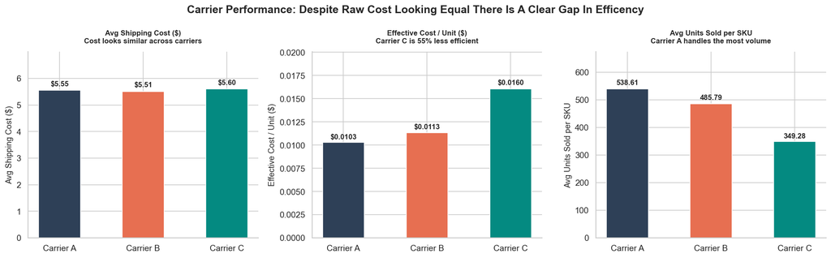

All three carriers charge near-identical average shipping costs (~$5.50). But Carrier C's effective cost per unit sold is **55% higher** than Carrier A's because Carrier C's SKUs sell far fewer units on average. This is the core inefficiency: the same shipping spend is spread over far fewer units with Carrier C, making each unit disproportionately expensive to ship.

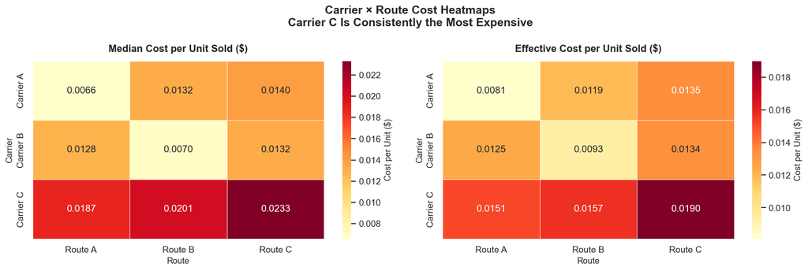

Both heatmaps tell a consistent story: **Carrier C is the most expensive operator across all three routes**, and this is not distorted by outliers (the median heatmap confirms it). Carrier A × Route A is the clear benchmark — the cheapest combination with the highest average volume.

## Supplier Efficiency

Now, let's move on to the analysis of supplier efficiency.

### SUPPLIER PERFORMANCE SCORECARD

| supplier_name | n_skus | avg_lead_time | avg_defect_rate | avg_risk_score | avg_mfg_cost | fail_rate_pct | pass_rate_pct | revenue_per_cost |
| --- | --- | --- | --- | --- | --- | --- | --- | --- |
| Supplier 1 | 27 | 22.8519 | 1.8036 | 0.4586 | 45.2540 | 22.2000 | 48.1000 | 128.9300 |
| Supplier 2 | 22 | 21.7273 | 2.3628 | 0.4989 | 41.6225 | 36.4000 | 22.7000 | 137.0200 |
| Supplier 3 | 15 | 19.5333 | 2.4658 | 0.4771 | 43.6341 | 20.0000 | 13.3000 | 149.4200 |
| Supplier 4 | 18 | 22.5556 | 2.3374 | 0.5085 | 62.7097 | 66.7000 | 0.0000 | 76.6000 |
| Supplier 5 | 18 | 20.9444 | 2.6654 | 0.5181 | 44.7682 | 38.9000 | 16.7000 | 136.9300 |

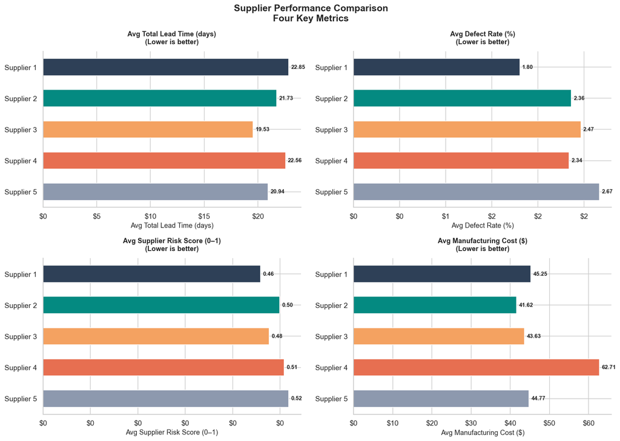

**Supplier 3** stands out positively, it has the shortest lead time, defect rates within an acceptable range of average and competitive costs, making it the benchmark for what good supplier performance looks like in this dataset.

### Financial Impact Quantification

```
#1 - MANUFACTURING COST PREMIUM

Supplier 4 avg mfg cost:          $62.71
Supplier 3 avg mfg cost (best):   $43.63
All other suppliers avg:          $43.88

Premium vs. Supplier 3:           $19.08/SKU
Premium vs. all others:           $18.83/SKU
Supplier 4 SKU count:             18

→ Estimated saving if matched Supplier 3: $343.36
→ Estimated saving vs. dataset avg:       $338.99
```

```
#2 - REVENUE DELAY OPPORTUNITY COST

Supplier 3 avg total lead time:  19.5 days (benchmark)
Supplier 4 avg total lead time:  22.6 days
Excess lead time vs. benchmark:  3.0 days per SKU

Avg revenue per SKU:             $5,776
Avg total lead time:             21.7 days
Implied daily revenue per SKU:   $266.05

→ Delay cost per Supplier 4 SKU: $804.08
→ Total delay cost (18 SKUs):    $14,473.38
```

```
#3 - DEFECT-RELATED MANUFACTURING WASTE

Supplier 4 avg defect rate:  2.337%
Other suppliers avg:         2.264%
Supplier 4 defect multiple:  1.03×

Supplier 4 est. waste:       $26.38
All others combined:         $81.45


CONSOLIDATED FINANCIAL IMPACT - SUPPLIER 4

  Mfg cost premium (vs avg):  $    338.99
  Revenue delay opp cost:     $  14473.38
  Defect-related waste:       $     26.38
  ─────────────────────────────────────────
  Total estimated impact:     $  14838.75
```

Revenue delay is the dominant component by far. Reducing Supplier 4's lead time to match Supplier 3's or at least the dataset average should be the priority.

## Inventory Risk

To finish off the exploratory data analysis section, I will look at the inventory to assess if there is any excess that poses financial risk.

### INVENTORY LANDSCAPE SUMMARY

|  | Mean | Median | Std Dev | Min | Max |
| --- | --- | --- | --- | --- | --- |
| Stock Levels (units) | 47.7700 | 47.5000 | 31.3690 | 0.0000 | 100.0000 |
| Units Sold | 460.9900 | 392.5000 | 303.7800 | 8.0000 | 996.0000 |
| Stock-to-Sales Ratio (SSR) | 0.2170 | 0.1150 | 0.4220 | 0.0000 | 3.8750 |
| Working Capital at Risk ($) | 10.4560 | 3.9900 | 26.9530 | 0.0000 | 256.9600 |

```
SKUs with SSR > 1.0 (more stock than units sold): 2
SKUs with SSR > 0.5 (moderate overstock):         11
Total working capital at risk across all SKUs:    $1045.5900
```

### CATEGORY INVENTORY SUMMARY

| product_type | n_skus | overall_ssr | avg_ssr | med_ssr | total_wcar | avg_wcar | wcar_share_pct |
| --- | --- | --- | --- | --- | --- | --- | --- |
| cosmetics | 26 | 0.1300 | 0.2110 | 0.1210 | 236.9800 | 9.1150 | 22.7000 |
| haircare | 34 | 0.1210 | 0.3250 | 0.1220 | 570.9900 | 16.7940 | 54.6000 |
| skincare | 40 | 0.0780 | 0.1280 | 0.0960 | 237.6200 | 5.9400 | 22.7000 |

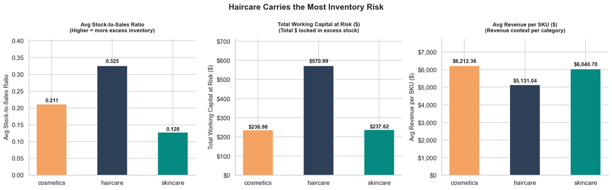

**Haircare holds the most working capital at risk (`~$571` total, 54% of all categories)** and has the highest average SSR. Critically, haircare also has the lowest average revenue per SKU (`~$5,131`), meaning it generates the least return while tying up the most capital.

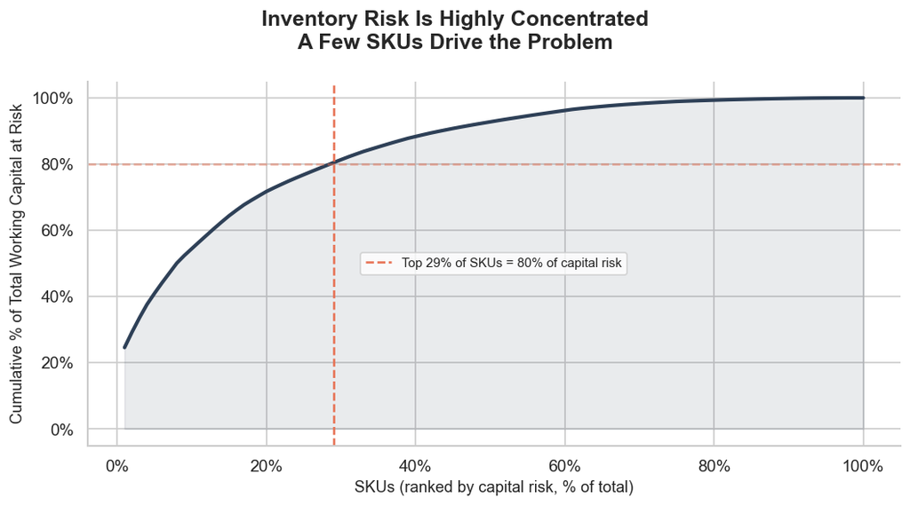

The cumulative capital risk curve has a steep initial slope, meaning that a small number of SKUs account for a disproportionate share of total capital risk. The implication is that targeted action on the top 5–10 SKUs will recover the majority of trapped capital, rather than requiring a broad portfolio-wide intervention.

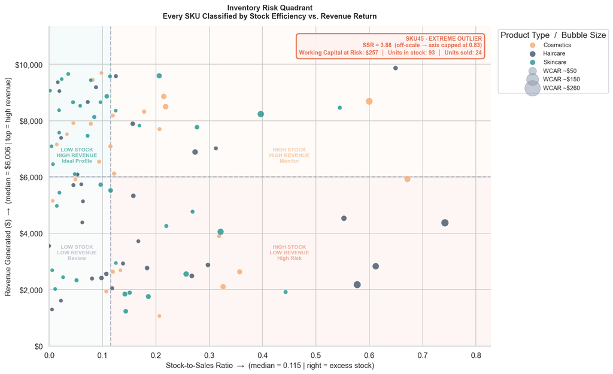

**30 SKUs sit in the 'High Stock / Low Revenue' danger zone** — these are the highest-priority reduction targets. Notably, the largest bubbles (highest capital risk) are overwhelmingly haircare SKUs clustered in this quadrant. The 'Low Stock / High Revenue' quadrant in the top-left is the ideal profile, dominated by skincare — confirming that skincare's inventory management is the internal benchmark to replicate.

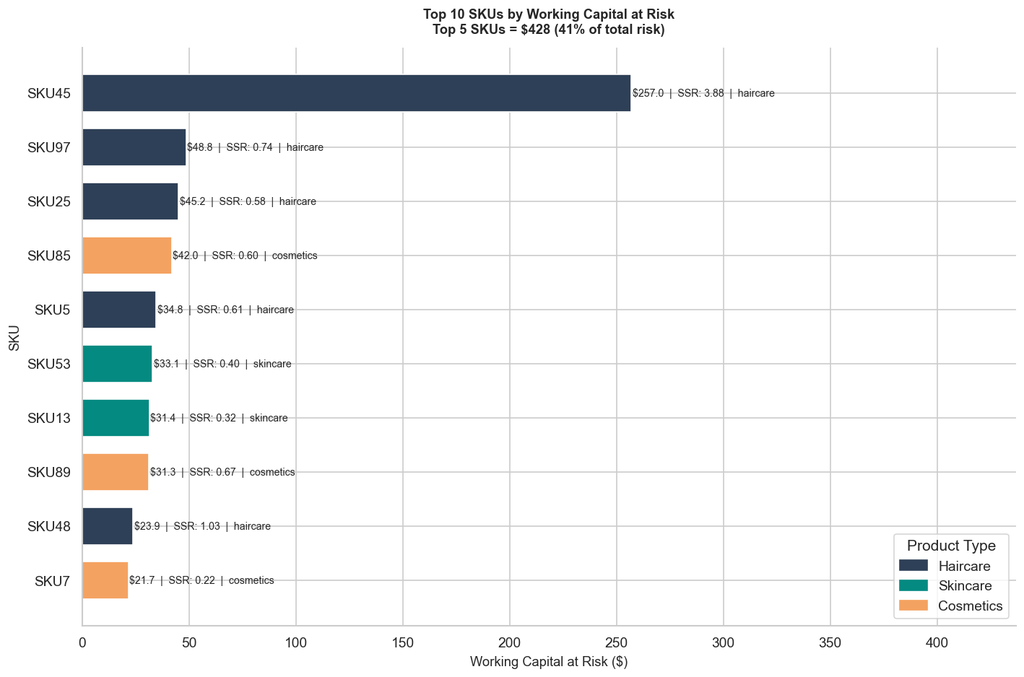

That concludes this notebook and part of the analysis. The final findings, recommendations and summary can be found in `Notebook 03: Summary`